# imgseg数据集的异常点检测

```python
import pandas as pd
from sklearn import metrics
from scipy import interpolate
import numpy as np
import os
import csv
import collections
from sklearn.decomposition import PCA, KernelPCA
import matplotlib.pyplot as plt
from pyod.utils.utility import standardizer
from pyod.utils.data import evaluate_print
from pyod.utils.example import visualize
from pyod.models.pca import PCA
from pyod.models.knn import KNN
from pyod.models.lof import LOF
from pyod.models.abod import ABOD
from pyod.models.loda import LODA
from pyod.models.lscp import LSCP
from sklearn.datasets import make_classification
from pyod.models.combination import aom, moa, average, maximization
from pyod.utils.utility import precision_n_scores
import time
from sklearn.metrics import roc_auc_score
```

### 获取异常点比例

```python
data = pd.read_csv('data/imgseg/meta_data/meta_imgseg.csv')
```

```python
ar = data['anomaly.rate']
ar_level = data['anomaly.rate.level']
```

```python
set(ar_level)
```

```
{'ar-0', 'ar-1', 'ar-2', 'ar-3', 'ar-4', 'ar-6'}
```

```python
data_dic = collections.defaultdict(list)
for item in data.iterrows():
    data_dic[item[1]['anomaly.rate.level']].append(item[1]['bench.id'])
for item in data_dic:
    print(len(data_dic[item]))
```

```
120
120
120
120
120
120
```

```python
ar_mean = [np.mean(ar[:120]), np.mean(ar[120:240]), np.mean(ar[240:360]),
           np.mean(ar[360:480]), np.mean(ar[480:600]), np.mean(ar[600:720])]
```

```python
ar_mean
```

```
[0.4281092436974788,
 0.001685838003032082,
 0.005040141475648629,
 0.010003968253968262,
 0.05035971223021575,
 0.09999999999999978]
```

### 可以看到，数据集一共分为6个异常点比例等级，个数均为120，异常点平均比例如上

```python
data = pd.read_csv('data/imgseg/benchmarks/imgseg_benchmark_0001.csv')
```

### 观察其中一个csv数据，选择特征属性

```python
data.head(5)
```

|  | point.id | motherset | origin | original.label | diff.score | ground.truth | REGION.CENTROID.COL | REGION.CENTROID.ROW | SHORT.LINE.DENSITY.5 | SHORT.LINE.DENSITY.2 | ... | INTENSITY.MEAN | RAWRED.MEAN | RAWBLUE.MEAN | RAWGREEN.MEAN | EXRED.MEAN | EXBLUE.MEAN | EXGREEN.MEAN | VALUE.MEAN | SATURATION.MEAN | HUE.MEAN |
| --- | --- | --- | --- | --- | --- | --- | --- | --- | --- | --- | --- | --- | --- | --- | --- | --- | --- | --- | --- | --- | --- |
| 0 | imgseg_point_2056 | imgseg | multiclass | BRICKFACE | 0.000129 | nominal | 0.974363 | 0.097117 | -0.35697 | -0.19451 | ... | -0.804640 | -0.711607 | -0.846696 | -0.835089 | 1.498462 | -0.940579 | 0.091011 | -0.860059 | 0.495952 | 0.278331 |
| 1 | imgseg_point_0348 | imgseg | multiclass | WINDOW | 0.002989 | anomaly | 0.851002 | -1.520728 | -0.35697 | -0.19451 | ... | -0.773595 | -0.800403 | -0.716510 | -0.807590 | 0.385774 | -0.253651 | 0.042918 | -0.748745 | 0.971331 | -0.475234 |
| 2 | imgseg_point_1699 | imgseg | multiclass | FOLIAGE | 0.000577 | nominal | -0.259248 | 0.218891 | -0.35697 | -0.19451 | ... | -0.952103 | -0.933596 | -0.971777 | -0.935919 | 0.942118 | -0.912194 | 0.600799 | -1.007614 | 2.347998 | -0.473359 |
| 3 | imgseg_point_2160 | imgseg | multiclass | SKY | 0.004510 | anomaly | 0.206783 | -1.555521 | -0.35697 | -0.19451 | ... | 1.792465 | 1.666846 | 1.910184 | 1.752886 | -2.597381 | 2.255626 | -1.217126 | 1.915016 | -0.627958 | -0.597760 |
| 4 | imgseg_point_1577 | imgseg | multiclass | GRASS | 0.001177 | nominal | 0.289023 | 1.993302 | -0.35697 | -0.19451 | ... | -0.504862 | -0.508646 | -0.634825 | -0.340104 | 0.376182 | -1.281205 | 1.793512 | -0.544239 | -0.488974 | 2.394541 |

5 rows × 24 columns

```python
data.columns
```

```
Index(['point.id', 'motherset', 'origin', 'original.label', 'diff.score',
       'ground.truth', 'REGION.CENTROID.COL', 'REGION.CENTROID.ROW',
       'SHORT.LINE.DENSITY.5', 'SHORT.LINE.DENSITY.2', 'VEDGE.MEAN',
       'VEDGE.SD', 'HEDGE.MEAN', 'HEDGE.SD', 'INTENSITY.MEAN', 'RAWRED.MEAN',
       'RAWBLUE.MEAN', 'RAWGREEN.MEAN', 'EXRED.MEAN', 'EXBLUE.MEAN',
       'EXGREEN.MEAN', 'VALUE.MEAN', 'SATURATION.MEAN', 'HUE.MEAN'],
      dtype='object')
```

### 选择groundtruth之后的属性为特征

### 定义评估函数

```python
def evaluation(y, y_scores, method):
    '''
    评估函数，y为groundtruth，y_scores为预测值，返回PR曲线，ROC曲线和AUC
    '''
    if isinstance(y_scores, dict):
        colors = ['r', 'g', 'b', '#FF1493', '#483D8B']
        plt.figure(figsize=(7,7))
        i = 0
        for algo in y_scores:
            pre_scr = y_scores[algo]
            print(algo, pre_scr.shape)
            fpr_level = np.arange(0, 1, 0.01)
            fpr, tpr, threshold = metrics.roc_curve(y, pre_scr)
            interp = interpolate.interp1d(fpr, tpr)
            tpr_at_fpr = [interp(x) for x in fpr_level]
            roc_auc = metrics.auc(fpr, tpr)
            plt.plot(fpr, tpr, color=colors[i], label='%s ROC(area = %0.2f)' % (algo, roc_auc))
            i += 1
        plt.xlabel('FPR')
        plt.ylabel('TPR')
        plt.title('Models Compare' + '-ROC')
        plt.plot([0, 1], [0, 1], color='navy', linestyle='--')
        plt.legend(loc="lower right")
    else:
        fpr_level = np.arange(0, 1, 0.01)
        fpr, tpr, threshold = metrics.roc_curve(y, y_scores)
        interp = interpolate.interp1d(fpr, tpr)
        tpr_at_fpr = [interp(x) for x in fpr_level]
        roc_auc = metrics.auc(fpr, tpr)
        precision, recall, _ = metrics.precision_recall_curve(y, y_scores)
        pr_auc = round(precision_n_scores(y, y_scores), ndigits=4)
#         pr_auc_t = metrics.auc(recall, precision)
        plt.figure(figsize=(12,5))
        plt.subplot(1, 2, 1)
        plt.xlabel('FPR')
        plt.ylabel('TPR')
        plt.title(method + '-ROC')
        plt.plot([0, 1], [0, 1], color='navy', linestyle='--')
        plt.plot(fpr, tpr, color='r', label='ROC curve (area = %0.2f)' % roc_auc)
        plt.legend(loc="lower right")
        plt.subplot(1, 2, 2)
        plt.plot(recall, precision, marker='.', label='precision @ rank n: %0.2f)' % pr_auc)
        plt.legend(loc="upper right")
        plt.xlabel('Recall')
        plt.ylabel('Precision')
        plt.title(method + '-PR')
        plt.show()
```

### 对原始数据集进行抽样，每一个异常点level选择一个benchmark，共6个benchmark进行拼接，并读取groundturth和特征属性

```python
path = 'data/imgseg/benchmarks/'
samples = []
for item in data_dic:
    samples.append(data_dic[item][0])
y = []
x_train = []
contam = 0
for sample in samples:
    p = os.path.join(path, sample+'.csv')
    data = pd.read_csv(p)
    data = data.dropna()
    for i in data.iterrows():
        # 0为正常，1为异常点
        if i[1][5] == 'anomaly':
            y.append(1)
            contam += 1
        else:
            y.append(0)
        x_train.append(list(i[1][6:24]))
x_train = np.array(x_train)
y = np.array(y)
contam /= len(y)
```

```python
contam
```

```
0.10292716133424099
```

### 使用算法在抽样集合中进行离群点检测，该部分用到的算法分别为Proximity-Based(KNN，LOF)，Linear Model(PCA)，Outlier Ensembles(LODA)，算法组合（PCA+KNN）

```python
algorithms = ['KNN', 'LOF', 'PCA', 'LODA']
all_scores = {}
# all_scores = collections.defaultdict(list)
```

### 首先对比分析算法在同一个benchmark上的表现，这里我们选择抽样的6个数据集进行测试

### 1.KNN

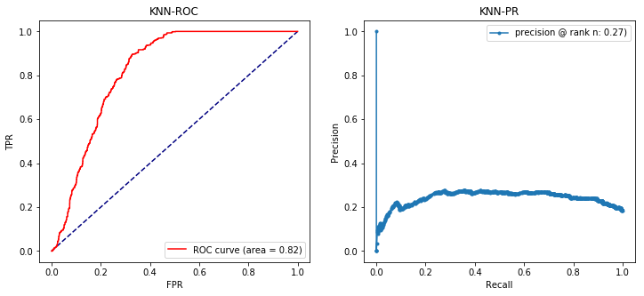

```python
clf_name = 'KNN'
clf = KNN(n_neighbors=5, contamination=contam)
x_train = standardizer(x_train)
clf.fit(x_train)
knn_y_pred = clf.labels_  # binary labels (0: inliers, 1: outliers)
knn_y_scores = clf.decision_scores_  # raw outlier scores
evaluation(y, knn_y_scores, clf_name)
all_scores['KNN'] = knn_y_scores
```

### 2.LOF

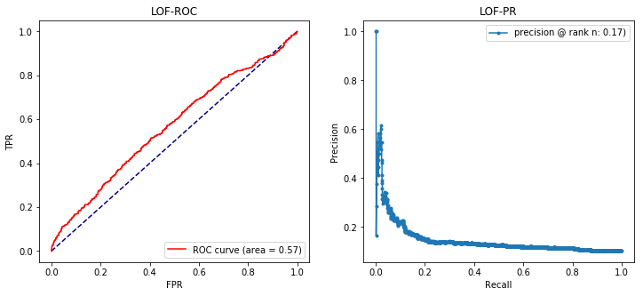

```python
clf_name = 'LOF'
clf = LOF(contamination=contam)
x_train = standardizer(x_train)
clf.fit(x_train)
y_pred = clf.labels_  # binary labels (0: inliers, 1: outliers)
y_scores = clf.decision_scores_  # raw outlier scores
evaluation(y, y_scores, clf_name)
all_scores['LOF'] = y_scores
```

### 3.PCA

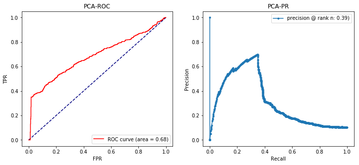

```python
clf_name = 'PCA'
clf = PCA(contamination=contam)
x_train = standardizer(x_train)
clf.fit(x_train)
y_pred = clf.labels_  # binary labels (0: inliers, 1: outliers)
y_scores = clf.decision_scores_  # raw outlier scores
evaluation(y, y_scores, clf_name)
all_scores['PCA'] = y_scores
```

### 4.LODA

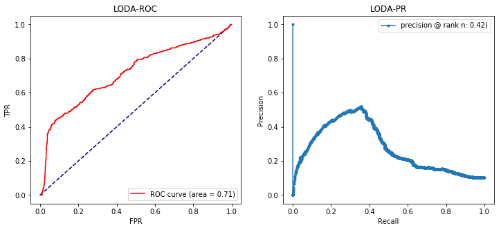

```python
clf_name = 'LODA'
clf = LODA(contamination=contam)
x_train = standardizer(x_train)
clf.fit(x_train)
y_pred = clf.labels_  # binary labels (0: inliers, 1: outliers)
y_scores = clf.decision_scores_  # raw outlier scores
evaluation(y, y_scores, clf_name)
all_scores['LODA'] = y_scores
```

### 5.PCA+KNN

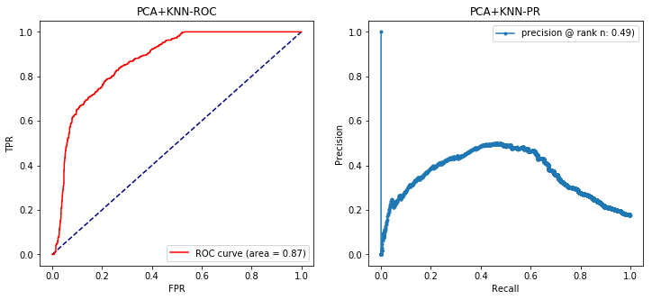

```python
pca = PCA(n_components=2)
kpca = KernelPCA(n_components=2, kernel="poly")
x_train_pca = kpca.fit_transform(x_train)
clf = KNN(n_neighbors=5, contamination=contam)
x_train_pca = standardizer(x_train_pca)
clf.fit(x_train_pca)
y_pred_pca = clf.labels_  # binary labels (0: inliers, 1: outliers)
y_scores = clf.decision_scores_  # raw outlier scores
evaluation(y, y_scores, 'PCA+KNN')
all_scores['PCA+KNN'] = y_scores
```

[output not shown]

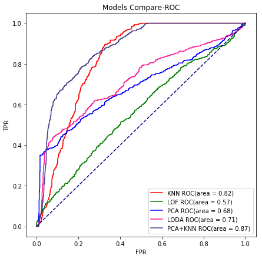

```python
evaluation(y, all_scores, algorithms)
```

### 可以看到，在同一个抽样的benchmark下，PCA+KNN表现最好，ROC-AUC达到了0.87，LOF表现最差，仅有0.57

### 对PCA+KNN进行可视化

[figure not shown]

```python
visualize(clf_name, x_train_pca, y, x_train_pca, y, y_pred, y_pred,
         show_figure=True, save_figure=False)
```

### 在所有样本上进行模型benchmark测试，输出auc到表格

```python
results = collections.defaultdict(list)
with open('results_imgseg.csv', 'w', newline='', encoding='utf-8') as f:
    csv_writer = csv.writer(f)
    csv_writer.writerow(['benchmark_id', 'Model', 'ROC', 'precision at rank n', 'execution time'])
    for item in data_dic:
        for bench_id in data_dic[item]:
            x_item = []
            y_item = []
            contam = 0
            p = os.path.join(path, bench_id+'.csv')
            for i in pd.read_csv(p).iterrows():
                if i[1][5] == 'anomaly':
                    y_item.append(1)
                    contam += 1
                else:
                    y_item.append(0)
                x_item.append(list(i[1][6:17]))
            x_item = np.array(x_item)
            y_item = np.array(y_item)
            contam /= len(y_item)
            contam = min(0.5, contam)
            # 定义模型
            classifiers = {'KNN': KNN(contamination=contam),
                           'LOF': LOF(contamination=contam),
                           'PCA': PCA(contamination=contam),
                           'LODA': LODA(contamination=contam)
                          }
            for cls in classifiers:
                clf = classifiers[cls]
                t0 = time.time()
                x_item = standardizer(x_item)
                clf.fit(x_item)
                y_scores = clf.decision_function(x_item)
                t1 = time.time()
                duration = round(t1 - t0, ndigits=4)

                roc = round(roc_auc_score(y_item, y_scores), ndigits=4)
                prn = round(precision_n_scores(y_item, y_scores), ndigits=4)
                results[cls].append(roc)

                print('benchmark id:{bench_id}, model:{clf_name}, ROC:{roc}, precision @ rank n:{prn}, '
                      'execution time: {duration}s'.format(
                    bench_id=bench_id, clf_name=cls, roc=roc, prn=prn, duration=duration))

                csv_writer.writerow([bench_id, cls, roc, prn, duration])

f.close()
```

```
benchmark id:imgseg_benchmark_0001, model:KNN, ROC:0.472, precision @ rank n:0.4222, execution time: 0.0971s
benchmark id:imgseg_benchmark_0001, model:LOF, ROC:0.5082, precision @ rank n:0.4861, execution time: 0.047s
benchmark id:imgseg_benchmark_0001, model:PCA, ROC:0.649, precision @ rank n:0.5619, execution time: 0.003s
benchmark id:imgseg_benchmark_0001, model:LODA, ROC:0.6163, precision @ rank n:0.573, execution time: 0.021s
benchmark id:imgseg_benchmark_0002, model:KNN, ROC:0.504, precision @ rank n:0.411, execution time: 0.0991s
benchmark id:imgseg_benchmark_0002, model:LOF, ROC:0.5485, precision @ rank n:0.4609, execution time: 0.05s
benchmark id:imgseg_benchmark_0002, model:PCA, ROC:0.6371, precision @ rank n:0.5116, execution time: 0.003s
benchmark id:imgseg_benchmark_0002, model:LODA, ROC:0.6456, precision @ rank n:0.5433, execution time: 0.02s
benchmark id:imgseg_benchmark_0003, model:KNN, ROC:0.4846, precision @ rank n:0.4127, execution time: 0.1041s
benchmark id:imgseg_benchmark_0003, model:LOF, ROC:0.4726, precision @ rank n:0.4203, execution time: 0.054s
benchmark id:imgseg_benchmark_0003, model:PCA, ROC:0.658, precision @ rank n:0.5624, execution time: 0.003s
benchmark id:imgseg_benchmark_0003, model:LODA, ROC:0.5387, precision @ rank n:0.4511, execution time: 0.02s
benchmark id:imgseg_benchmark_0004, model:KNN, ROC:0.4412, precision @ rank n:0.4195, execution time: 0.0961s
benchmark id:imgseg_benchmark_0004, model:LOF, ROC:0.4703, precision @ rank n:0.4738, execution time: 0.046s
benchmark id:imgseg_benchmark_0004, model:PCA, ROC:0.6276, precision @ rank n:0.5497, execution time: 0.003s
benchmark id:imgseg_benchmark_0004, model:LODA, ROC:0.4914, precision @ rank n:0.4177, execution time: 0.02s
benchmark id:imgseg_benchmark_0005, model:KNN, ROC:0.4779, precision @ rank n:0.391, execution time: 0.1043s
benchmark id:imgseg_benchmark_0005, model:LOF, ROC:0.5173, precision @ rank n:0.4676, execution time: 0.058s
benchmark id:imgseg_benchmark_0005, model:PCA, ROC:0.6336, precision @ rank n:0.5295, execution time: 0.003s
benchmark id:imgseg_benchmark_0005, model:LODA, ROC:0.5911, precision @ rank n:0.4774, execution time: 0.021s
benchmark id:imgseg_benchmark_0006, model:KNN, ROC:0.4902, precision @ rank n:0.3965, execution time: 0.1021s
benchmark id:imgseg_benchmark_0006, model:LOF, ROC:0.5068, precision @ rank n:0.4531, execution time: 0.051s
benchmark id:imgseg_benchmark_0006, model:PCA, ROC:0.665, precision @ rank n:0.5566, execution time: 0.002s
benchmark id:imgseg_benchmark_0006, model:LODA, ROC:0.6185, precision @ rank n:0.5684, execution time: 0.02s
benchmark id:imgseg_benchmark_0007, model:KNN, ROC:0.4803, precision @ rank n:0.4203, execution time: 0.1011s
benchmark id:imgseg_benchmark_0007, model:LOF, ROC:0.5106, precision @ rank n:0.4395, execution time: 0.052s
benchmark id:imgseg_benchmark_0007, model:PCA, ROC:0.6441, precision @ rank n:0.547, execution time: 0.003s
benchmark id:imgseg_benchmark_0007, model:LODA, ROC:0.3503, precision @ rank n:0.2668, execution time: 0.027s
benchmark id:imgseg_benchmark_0008, model:KNN, ROC:0.4702, precision @ rank n:0.4307, execution time: 0.1021s
benchmark id:imgseg_benchmark_0008, model:LOF, ROC:0.4916, precision @ rank n:0.458, execution time: 0.053s
benchmark id:imgseg_benchmark_0008, model:PCA, ROC:0.636, precision @ rank n:0.562, execution time: 0.003s
benchmark id:imgseg_benchmark_0008, model:LODA, ROC:0.6322, precision @ rank n:0.5858, execution time: 0.019s
benchmark id:imgseg_benchmark_0009, model:KNN, ROC:0.4904, precision @ rank n:0.4138, execution time: 0.0971s
benchmark id:imgseg_benchmark_0009, model:LOF, ROC:0.4883, precision @ rank n:0.4203, execution time: 0.0506s
benchmark id:imgseg_benchmark_0009, model:PCA, ROC:0.669, precision @ rank n:0.5709, execution time: 0.0025s
benchmark id:imgseg_benchmark_0009, model:LODA, ROC:0.7458, precision @ rank n:0.6628, execution time: 0.019s
benchmark id:imgseg_benchmark_0010, model:KNN, ROC:0.5003, precision @ rank n:0.3883, execution time: 0.0971s
benchmark id:imgseg_benchmark_0010, model:LOF, ROC:0.5052, precision @ rank n:0.3996, execution time: 0.048s
benchmark id:imgseg_benchmark_0010, model:PCA, ROC:0.656, precision @ rank n:0.5282, execution time: 0.003s
benchmark id:imgseg_benchmark_0010, model:LODA, ROC:0.6718, precision @ rank n:0.5846, execution time: 0.021s
```

[output cut: 2825 more lines]

```
benchmark id:imgseg_benchmark_1617, model:LOF, ROC:0.5878, precision @ rank n:0.1364, execution time: 0.0591s
benchmark id:imgseg_benchmark_1617, model:PCA, ROC:0.7351, precision @ rank n:0.3258, execution time: 0.003s
benchmark id:imgseg_benchmark_1617, model:LODA, ROC:0.6135, precision @ rank n:0.1591, execution time: 0.022s
benchmark id:imgseg_benchmark_1618, model:KNN, ROC:0.6956, precision @ rank n:0.1667, execution time: 0.1161s
benchmark id:imgseg_benchmark_1618, model:LOF, ROC:0.6508, precision @ rank n:0.1288, execution time: 0.0601s
benchmark id:imgseg_benchmark_1618, model:PCA, ROC:0.7177, precision @ rank n:0.3485, execution time: 0.003s
benchmark id:imgseg_benchmark_1618, model:LODA, ROC:0.6424, precision @ rank n:0.2879, execution time: 0.021s
benchmark id:imgseg_benchmark_1619, model:KNN, ROC:0.753, precision @ rank n:0.1439, execution time: 0.1141s
benchmark id:imgseg_benchmark_1619, model:LOF, ROC:0.6142, precision @ rank n:0.1591, execution time: 0.0601s
benchmark id:imgseg_benchmark_1619, model:PCA, ROC:0.7222, precision @ rank n:0.3864, execution time: 0.003s
benchmark id:imgseg_benchmark_1619, model:LODA, ROC:0.7338, precision @ rank n:0.3636, execution time: 0.021s
benchmark id:imgseg_benchmark_1620, model:KNN, ROC:0.7467, precision @ rank n:0.1667, execution time: 0.1124s
benchmark id:imgseg_benchmark_1620, model:LOF, ROC:0.6636, precision @ rank n:0.1667, execution time: 0.0611s
benchmark id:imgseg_benchmark_1620, model:PCA, ROC:0.7845, precision @ rank n:0.4394, execution time: 0.003s
benchmark id:imgseg_benchmark_1620, model:LODA, ROC:0.6319, precision @ rank n:0.3485, execution time: 0.021s
```

### 结果输出在csv文件，这里对结果进行分析

```python
ar_mean
```

```
[0.001685838003032082,
 0.005040141475648629,
 0.010003968253968262,
 0.05035971223021575,
 0.09999999999999978,
 0.4281092436974788]
```

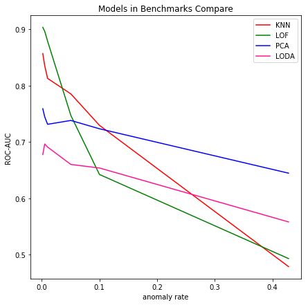

```python
ar_mean.sort()
plt.figure(figsize=(7,7))
plt.xlabel('anomaly rate')
plt.ylabel('ROC-AUC')
colors = ['r', 'g', 'b', '#FF1493', '#483D8B']
i = 0
for cls in classifiers:
    mean_y = [np.mean(results[cls][120:240]), np.mean(results[cls][240:360]), np.mean(results[cls][360:480]),
              np.mean(results[cls][480:600]), np.mean(results[cls][600:720]), np.mean(results[cls][:120])]
    plt.plot(ar_mean, mean_y, color=colors[i], label=cls)
    i += 1
plt.title('Models in Benchmarks Compare')
plt.legend(loc="upper right")
plt.show()
```

### 可以看到，所有算法在高异常点比例下表现均较差，在低异常点比例下表现较好。其中，KNN和LOF在不同异常点下的差异最为明显，低异常点下表现最好，高异常点下基本表现最差。相反，PCA在不同异常点比例下表现较为鲁棒。

### 因此可以得出结论，Proximity-Based(KNN，LOF)的方法对异常点比例较为敏感，Linear Model(PCA)和Outlier Ensembles(LODA)方法较为鲁棒。这也符合基本常识。